# 社交媒体使用对生产力影响的分析报告

## 6. 回归模型：预测生产力得分

本节使用多种回归模型预测 `productivity_score`，并比较各模型的性能。

```python
# 导入回归模型相关库
from sklearn.model_selection import train_test_split, cross_val_score
from sklearn.linear_model import LinearRegression, Ridge, Lasso
from sklearn.ensemble import RandomForestRegressor, GradientBoostingRegressor
from sklearn.metrics import mean_squared_error, mean_absolute_error, r2_score
import time

# 准备特征和目标变量（回归）
feature_cols = ['age', 'daily_screen_time', 'social_media_hours', 'study_hours',
                'sleep_hours', 'notifications_per_day', 'focus_score',
                'social_media_ratio', 'work_efficiency', 'sleep_adequate', 'high_notifications']

X_reg = df_clean[feature_cols].copy()
y_reg = df_clean['productivity_score'].copy()

# 处理无穷大和 NaN 值
X_reg = X_reg.replace([float('inf'), float('-inf')], float('nan'))
X_reg = X_reg.fillna(X_reg.median())

# 划分训练集和测试集
X_train_reg, X_test_reg, y_train_reg, y_test_reg = train_test_split(
    X_reg, y_reg, test_size=0.2, random_state=42)

# 标准化特征
scaler_reg = StandardScaler()
X_train_reg_scaled = scaler_reg.fit_transform(X_train_reg)
X_test_reg_scaled = scaler_reg.transform(X_test_reg)

print("=" * 60)
print("回归模型数据准备完成")
print("=" * 60)
print(f"训练集大小: {X_train_reg.shape[0]}")
print(f"测试集大小: {X_test_reg.shape[0]}")
print(f"特征数量: {X_train_reg.shape[1]}")
```

```
============================================================
回归模型数据准备完成
============================================================
训练集大小: 4800
测试集大小: 1200
特征数量: 11
```

### 6.1 训练多个回归模型

```python
from joblib import dump as joblib_dump
from sklearn.linear_model import LinearRegression, Ridge, Lasso
from sklearn.ensemble import RandomForestRegressor, GradientBoostingRegressor
from sklearn.metrics import mean_squared_error, mean_absolute_error, r2_score
from sklearn.model_selection import cross_val_score
import time

# 定义回归模型
regression_models = {
    '线性回归': LinearRegression(),
    '岭回归': Ridge(alpha=1.0),
    'Lasso回归': Lasso(alpha=0.1),
    '随机森林回归': RandomForestRegressor(n_estimators=100, max_depth=10, random_state=42, n_jobs=-1),
    '梯度提升回归': GradientBoostingRegressor(n_estimators=100, max_depth=5, random_state=42)
}

# 存储结果
reg_results = []

print("=" * 70)
print("回归模型训练与评估")
print("=" * 70)

for name, model in regression_models.items():
    start_time = time.time()

    if name in ['线性回归', '岭回归', 'Lasso回归']:
        model.fit(X_train_reg_scaled, y_train_reg)
        y_pred = model.predict(X_test_reg_scaled)
    else:
        model.fit(X_train_reg, y_train_reg)
        y_pred = model.predict(X_test_reg)

    train_time = time.time() - start_time

    # 保存模型
    model_filename = f'{model_dir}regression_{name}.pkl'
    joblib_dump(model, model_filename)

    mse = mean_squared_error(y_test_reg, y_pred)
    rmse = mse ** 0.5
    mae = mean_absolute_error(y_test_reg, y_pred)
    r2 = r2_score(y_test_reg, y_pred)

    if name in ['线性回归', '岭回归', 'Lasso回归']:
        cv_scores = cross_val_score(model, X_train_reg_scaled, y_train_reg, cv=5, scoring='r2')
    else:
        cv_scores = cross_val_score(model, X_train_reg, y_train_reg, cv=5, scoring='r2')

    reg_results.append({
        'Model': name,
        'RMSE': rmse,
        'MAE': mae,
        'R2': r2,
        'CV_R2_Mean': cv_scores.mean(),
        'CV_R2_Std': cv_scores.std(),
        'Train_Time': train_time
    })

    print(f"\n{name}:")
    print(f"  RMSE: {rmse:.4f}")
    print(f"  MAE: {mae:.4f}")
    print(f"  R2: {r2:.4f}")
    print(f"  交叉验证 R2: {cv_scores.mean():.4f} (+/- {cv_scores.std()*2:.4f})")
    print(f"  训练时间: {train_time:.4f}秒")
    print(f"  模型已保存: {model_filename}")

print("\n" + "=" * 70)
```

```
======================================================================
回归模型训练与评估
======================================================================

线性回归:
  RMSE: 11.1724
  MAE: 8.5130
  R2: 0.8306
  交叉验证 R2: 0.8392 (+/- 0.0120)
  训练时间: 0.0050秒
  模型已保存: ./Model/regression_线性回归.pkl

岭回归:
  RMSE: 11.1704
  MAE: 8.5123
  R2: 0.8307
  交叉验证 R2: 0.8392 (+/- 0.0120)
  训练时间: 0.0012秒
  模型已保存: ./Model/regression_岭回归.pkl

Lasso回归:
  RMSE: 11.1313
  MAE: 8.5233
  R2: 0.8319
  交叉验证 R2: 0.8385 (+/- 0.0118)
  训练时间: 0.0018秒
  模型已保存: ./Model/regression_Lasso回归.pkl

随机森林回归:
  RMSE: 10.8740
  MAE: 8.1346
  R2: 0.8396
  交叉验证 R2: 0.8408 (+/- 0.0163)
  训练时间: 0.2563秒
  模型已保存: ./Model/regression_随机森林回归.pkl

梯度提升回归:
  RMSE: 10.9102
  MAE: 8.1413
  R2: 0.8385
  交叉验证 R2: 0.8427 (+/- 0.0106)
  训练时间: 0.8534秒
  模型已保存: ./Model/regression_梯度提升回归.pkl

======================================================================
```

### 6.2 回归模型结果对比

```python
import pandas as pd

reg_results_df = pd.DataFrame(reg_results)
reg_results_df = reg_results_df.sort_values('R2', ascending=False)

print("=" * 70)
print("回归模型性能对比（按R2排序）")
print("=" * 70)
print(reg_results_df.to_string(index=False))

reg_results_df.to_csv(f'{describe_dir}regression_results.csv', index=False, encoding='utf-8-sig')
print(f"\n回归模型结果已保存至: {describe_dir}regression_results.csv")
```

```
======================================================================
回归模型性能对比（按R2排序）
======================================================================
  Model      RMSE      MAE       R2  CV_R2_Mean  CV_R2_Std  Train_Time
 随机森林回归 10.873976 8.134599 0.839557    0.840754   0.008155    0.256348
 梯度提升回归 10.910188 8.141256 0.838486    0.842712   0.005292    0.853440
Lasso回归 11.131317 8.523346 0.831873    0.838461   0.005924    0.001788
    岭回归 11.170429 8.512271 0.830689    0.839226   0.005990    0.001167
   线性回归 11.172420 8.513038 0.830629    0.839225   0.005999    0.004993

回归模型结果已保存至: ./Describe/regression_results.csv
```

### 6.3 回归模型可视化对比

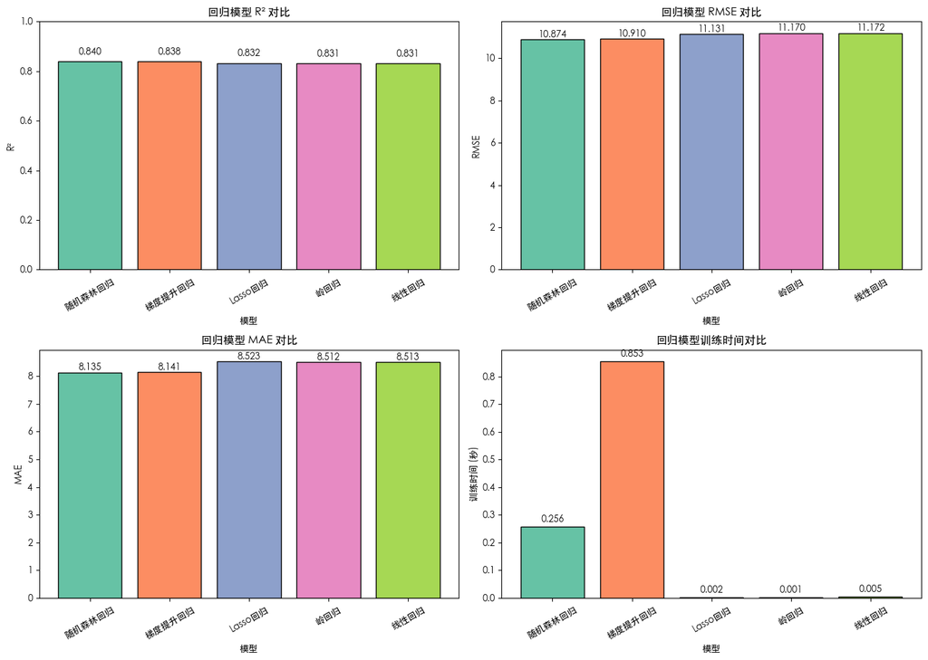

```
图片已保存至: ./Image/08_regression_comparison.png
```

```python
# 可视化回归模型对比
fig, axes = plt.subplots(2, 2, figsize=(14, 10))

# 设置x轴和y轴标签字体
for ax in axes.flat:
    for label in ax.get_xticklabels():
        label.set_fontproperties(get_font())
    for label in ax.get_yticklabels():
        label.set_fontproperties(get_font())

colors = plt.cm.Set2(range(len(reg_results_df)))

ax1 = axes[0, 0]
bars = ax1.bar(reg_results_df['Model'], reg_results_df['R2'], color=colors, edgecolor='black')
ax1.set_xlabel('模型', fontproperties=get_font())
ax1.set_ylabel('R²', fontproperties=get_font())
ax1.set_title('回归模型 R² 对比', fontproperties=get_font(), fontsize=12, fontweight='bold')
ax1.set_ylim(0, 1)
for bar, val in zip(bars, reg_results_df['R2']):
    ax1.text(bar.get_x() + bar.get_width()/2, bar.get_height() + 0.02, f'{val:.3f}',
             ha='center', va='bottom', fontproperties=get_font())
ax1.tick_params(axis='x', rotation=30)

ax2 = axes[0, 1]
bars2 = ax2.bar(reg_results_df['Model'], reg_results_df['RMSE'], color=colors, edgecolor='black')
ax2.set_xlabel('模型', fontproperties=get_font())
ax2.set_ylabel('RMSE', fontproperties=get_font())
ax2.set_title('回归模型 RMSE 对比', fontproperties=get_font(), fontsize=12, fontweight='bold')
for bar, val in zip(bars2, reg_results_df['RMSE']):
    ax2.text(bar.get_x() + bar.get_width()/2, bar.get_height() + 0.02, f'{val:.3f}',
             ha='center', va='bottom', fontproperties=get_font())
ax2.tick_params(axis='x', rotation=30)

ax3 = axes[1, 0]
bars3 = ax3.bar(reg_results_df['Model'], reg_results_df['MAE'], color=colors, edgecolor='black')
ax3.set_xlabel('模型', fontproperties=get_font())
ax3.set_ylabel('MAE', fontproperties=get_font())
ax3.set_title('回归模型 MAE 对比', fontproperties=get_font(), fontsize=12, fontweight='bold')
for bar, val in zip(bars3, reg_results_df['MAE']):
    ax3.text(bar.get_x() + bar.get_width()/2, bar.get_height() + 0.01, f'{val:.3f}',
             ha='center', va='bottom', fontproperties=get_font())
ax3.tick_params(axis='x', rotation=30)

ax4 = axes[1, 1]
bars4 = ax4.bar(reg_results_df['Model'], reg_results_df['Train_Time'], color=colors, edgecolor='black')
ax4.set_xlabel('模型', fontproperties=get_font())
ax4.set_ylabel('训练时间 (秒)', fontproperties=get_font())
ax4.set_title('回归模型训练时间对比', fontproperties=get_font(), fontsize=12, fontweight='bold')
for bar, val in zip(bars4, reg_results_df['Train_Time']):
    ax4.text(bar.get_x() + bar.get_width()/2, bar.get_height() + 0.01, f'{val:.3f}',
             ha='center', va='bottom', fontproperties=get_font())
ax4.tick_params(axis='x', rotation=30)

plt.tight_layout()
plt.savefig(f'{image_dir}08_regression_comparison.png', dpi=150, bbox_inches='tight')
plt.show()
print(f"\n图片已保存至: {image_dir}08_regression_comparison.png")
```

## 7. 分类模型：预测成瘾程度

本节使用多种分类模型预测 `addiction_level`，使用以下评估指标：

- **Accuracy（准确率）**: 正确预测的比例
- **Precision（精确率）**: 预测为正类的样本中实际为正类的比例
- **Recall（召回率）**: 实际为正类的样本中被正确预测的比例
- **F1 Score**: 精确率和召回率的调和平均
- **AUC**: ROC曲线下面积，反映模型区分能力
- **训练时间**: 模型训练所需时间

```python
# 导入分类模型相关库
from sklearn.tree import DecisionTreeClassifier
from sklearn.ensemble import RandomForestClassifier, GradientBoostingClassifier
from sklearn.svm import SVC
from sklearn.linear_model import LogisticRegression
from sklearn.metrics import accuracy_score, precision_score, recall_score, f1_score, roc_auc_score, classification_report, confusion_matrix
from sklearn.metrics import roc_curve
from sklearn.preprocessing import label_binarize

# 准备特征和目标变量（分类）
X_clf = df_clean[feature_cols].copy()
y_clf = df_clean['addiction_level'].copy()

X_clf = X_clf.replace([float('inf'), float('-inf')], float('nan'))
X_clf = X_clf.fillna(X_clf.median())

X_train_clf, X_test_clf, y_train_clf, y_test_clf = train_test_split(
    X_clf, y_clf, test_size=0.2, random_state=42, stratify=y_clf)

scaler_clf = StandardScaler()
X_train_clf_scaled = scaler_clf.fit_transform(X_train_clf)
X_test_clf_scaled = scaler_clf.transform(X_test_clf)

class_labels = sorted(y_clf.unique())
n_classes = len(class_labels)

print("=" * 60)
print("分类模型数据准备完成")
print("=" * 60)
print(f"训练集大小: {X_train_clf.shape[0]}")
print(f"测试集大小: {X_test_clf.shape[0]}")
print(f"类别: {class_labels}")
print(f"类别数量: {n_classes}")
```

```
============================================================
分类模型数据准备完成
============================================================
训练集大小: 4800
测试集大小: 1200
类别: ['High', 'Low', 'Medium']
类别数量: 3
```

### 7.1 训练多个分类模型

```python
from joblib import dump as joblib_dump
from sklearn.tree import DecisionTreeClassifier
from sklearn.ensemble import RandomForestClassifier, GradientBoostingClassifier
from sklearn.svm import SVC
from sklearn.linear_model import LogisticRegression
from sklearn.metrics import accuracy_score, precision_score, recall_score, f1_score, roc_auc_score
from sklearn.preprocessing import label_binarize
import time

classification_models = {
    '决策树': DecisionTreeClassifier(max_depth=10, random_state=42),
    '随机森林': RandomForestClassifier(n_estimators=100, max_depth=10, random_state=42, n_jobs=-1),
    '支持向量机': SVC(kernel='rbf', probability=True, random_state=42),
    '逻辑回归': LogisticRegression(max_iter=1000, random_state=42),
    '梯度提升': GradientBoostingClassifier(n_estimators=100, max_depth=5, random_state=42)
}

clf_results = []

print("=" * 70)
print("分类模型训练与评估（训练集 vs 测试集 - 检测过拟合）")
print("=" * 70)

for name, model in classification_models.items():
    start_time = time.time()

    if name in ['支持向量机', '逻辑回归']:
        model.fit(X_train_clf_scaled, y_train_clf)
        y_pred_train = model.predict(X_train_clf_scaled)
        y_pred_test = model.predict(X_test_clf_scaled)
        y_pred_proba = model.predict_proba(X_test_clf_scaled)
    else:
        model.fit(X_train_clf, y_train_clf)
        y_pred_train = model.predict(X_train_clf)
        y_pred_test = model.predict(X_test_clf)
        y_pred_proba = model.predict_proba(X_test_clf)

    train_time = time.time() - start_time

    # 计算训练集和测试集准确率（用于检测过拟合）
    train_accuracy = accuracy_score(y_train_clf, y_pred_train)
    test_accuracy = accuracy_score(y_test_clf, y_pred_test)
    overfit_ratio = train_accuracy - test_accuracy

    # 保存模型
    model_filename = f'{model_dir}classification_{name}.pkl'
    joblib_dump(model, model_filename)

    accuracy = test_accuracy
    precision = precision_score(y_test_clf, y_pred_test, average='weighted')
    recall = recall_score(y_test_clf, y_pred_test, average='weighted')
    f1 = f1_score(y_test_clf, y_pred_test, average='weighted')

    y_test_bin = label_binarize(y_test_clf, classes=class_labels)
    try:
        auc = roc_auc_score(y_test_bin, y_pred_proba, multi_class='ovr', average='weighted')
    except:
        auc = 0

    clf_results.append({
        'Model': name,
        'Train_Acc': train_accuracy,
        'Test_Acc': test_accuracy,
        'Overfit': overfit_ratio,
        'Accuracy': accuracy,
        'Precision': precision,
        'Recall': recall,
        'F1': f1,
        'AUC': auc,
        'Train_Time': train_time
    })

    print(f"\n{name}:")
    print(f"  训练集准确率: {train_accuracy:.4f}")
    print(f"  测试集准确率: {test_accuracy:.4f}")
    print(f"  过拟合差值: {overfit_ratio:.4f}", end='')
    if overfit_ratio > 0.05:
        print(" ⚠️ 可能过拟合!")
    else:
        print(" ✓ 正常")
    print(f"  Precision: {precision:.4f}")
    print(f"  Recall: {recall:.4f}")
    print(f"  F1 Score: {f1:.4f}")
    print(f"  AUC: {auc:.4f}")
    print(f"  训练时间: {train_time:.4f}秒")
    print(f"  模型已保存: {model_filename}")

print("\n" + "=" * 70)
```

```
======================================================================
分类模型训练与评估（训练集 vs 测试集 - 检测过拟合）
======================================================================

决策树:
  训练集准确率: 0.9962
  测试集准确率: 0.9808
  过拟合差值: 0.0154 ✓ 正常
  Precision: 0.9809
  Recall: 0.9808
  F1 Score: 0.9808
  AUC: 0.9869
  训练时间: 0.0243秒
  模型已保存: ./Model/classification_决策树.pkl

随机森林:
  训练集准确率: 0.9908
  测试集准确率: 0.9892
  过拟合差值: 0.0017 ✓ 正常
  Precision: 0.9892
  Recall: 0.9892
  F1 Score: 0.9892
  AUC: 0.9950
  训练时间: 0.1305秒
  模型已保存: ./Model/classification_随机森林.pkl

支持向量机:
  训练集准确率: 0.9610
  测试集准确率: 0.9625
  过拟合差值: -0.0015 ✓ 正常
  Precision: 0.9630
  Recall: 0.9625
  F1 Score: 0.9624
  AUC: 0.9922
  训练时间: 0.5733秒
  模型已保存: ./Model/classification_支持向量机.pkl

逻辑回归:
  训练集准确率: 0.9550
  测试集准确率: 0.9650
  过拟合差值: -0.0100 ✓ 正常
  Precision: 0.9651
  Recall: 0.9650
  F1 Score: 0.9650
  AUC: 0.9903
  训练时间: 0.0129秒
  模型已保存: ./Model/classification_逻辑回归.pkl

梯度提升:
  训练集准确率: 1.0000
  测试集准确率: 0.9908
  过拟合差值: 0.0092 ✓ 正常
  Precision: 0.9910
  Recall: 0.9908
  F1 Score: 0.9909
  AUC: 0.9950
  训练时间: 2.7103秒
  模型已保存: ./Model/classification_梯度提升.pkl

======================================================================
```

### 7.2 分类模型结果对比

```python
clf_results_df = pd.DataFrame(clf_results)
clf_results_df = clf_results_df.sort_values('F1', ascending=False)

print("=" * 70)
print("分类模型性能对比（按F1排序）")
print("=" * 70)
print(clf_results_df.to_string(index=False))

clf_results_df.to_csv(f'{describe_dir}classification_results.csv', index=False, encoding='utf-8-sig')
print(f"\n分类模型结果已保存至: {describe_dir}classification_results.csv")
```

```
======================================================================
分类模型性能对比（按F1排序）
======================================================================
Model  Train_Acc  Test_Acc   Overfit  Accuracy  Precision   Recall       F1      AUC  Train_Time
 梯度提升   1.000000  0.990833  0.009167  0.990833   0.990973 0.990833 0.990851 0.995025    2.710261
 随机森林   0.990833  0.989167  0.001667  0.989167   0.989190 0.989167 0.989175 0.994989    0.130473
  决策树   0.996250  0.980833  0.015417  0.980833   0.980907 0.980833 0.980849 0.986862    0.024304
 逻辑回归   0.955000  0.965000 -0.010000  0.965000   0.965132 0.965000 0.964992 0.990349    0.012867
支持向量机   0.961042  0.962500 -0.001458  0.962500   0.962976 0.962500 0.962396 0.992177    0.573305

分类模型结果已保存至: ./Describe/classification_results.csv
```

### 7.3 分类模型可视化对比

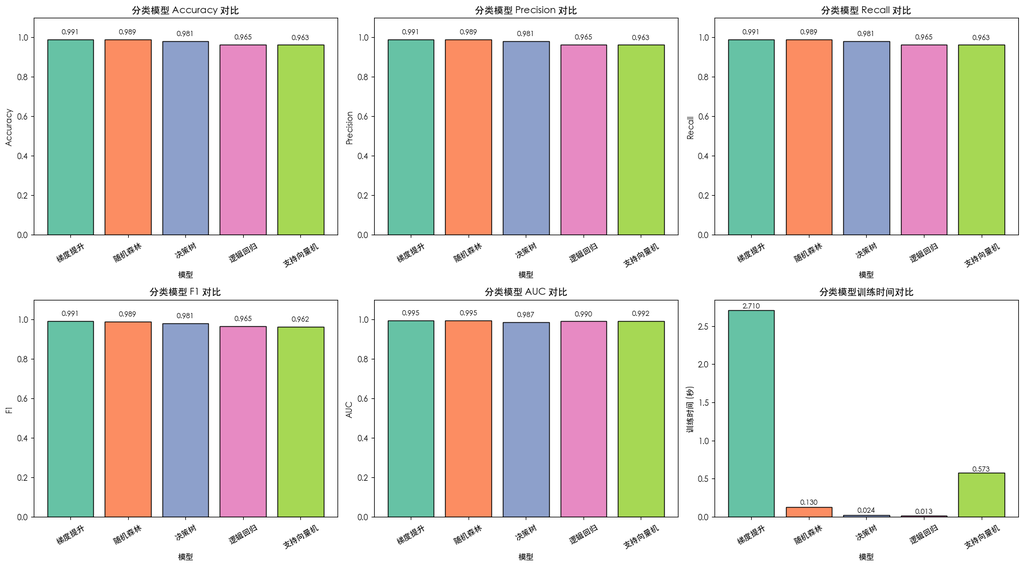

```
图片已保存至: ./Image/09_classification_comparison.png
```

```python
fig, axes = plt.subplots(2, 3, figsize=(18, 10))

# 设置x轴标签和y轴标签字体
for ax in axes.flat:
    for label in ax.get_xticklabels():
        label.set_fontproperties(get_font())
    for label in ax.get_yticklabels():
        label.set_fontproperties(get_font())

metrics = ['Accuracy', 'Precision', 'Recall', 'F1', 'AUC']
colors = plt.cm.Set2(range(len(clf_results_df)))

for idx, metric in enumerate(metrics):
    ax = axes[idx // 3, idx % 3]
    bars = ax.bar(clf_results_df['Model'], clf_results_df[metric], color=colors, edgecolor='black')
    ax.set_xlabel('模型', fontproperties=get_font())
    ax.set_ylabel(metric, fontproperties=get_font())
    ax.set_title(f'分类模型 {metric} 对比', fontproperties=get_font(), fontsize=12, fontweight='bold')
    ax.set_ylim(0, 1.1)
    for bar, val in zip(bars, clf_results_df[metric]):
        ax.text(bar.get_x() + bar.get_width()/2, bar.get_height() + 0.02, f'{val:.3f}',
                ha='center', va='bottom', fontproperties=get_font(), fontsize=9)
    ax.tick_params(axis='x', rotation=30)

ax_time = axes[1, 2]
bars_time = ax_time.bar(clf_results_df['Model'], clf_results_df['Train_Time'], color=colors, edgecolor='black')
ax_time.set_xlabel('模型', fontproperties=get_font())
ax_time.set_ylabel('训练时间 (秒)', fontproperties=get_font())
ax_time.set_title('分类模型训练时间对比', fontproperties=get_font(), fontsize=12, fontweight='bold')
for bar, val in zip(bars_time, clf_results_df['Train_Time']):
    ax_time.text(bar.get_x() + bar.get_width()/2, bar.get_height() + 0.01, f'{val:.3f}',
                 ha='center', va='bottom', fontproperties=get_font(), fontsize=9)
ax_time.tick_params(axis='x', rotation=30)

plt.tight_layout()
plt.savefig(f'{image_dir}09_classification_comparison.png', dpi=150, bbox_inches='tight')
plt.show()
print(f"\n图片已保存至: {image_dir}09_classification_comparison.png")
```

### 7.4 混淆矩阵可视化

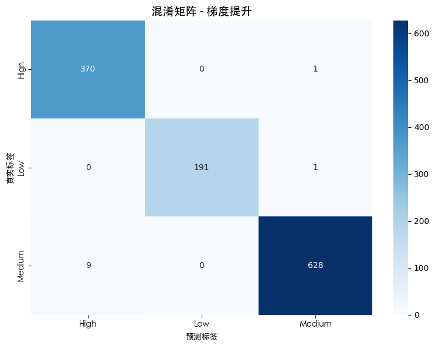

```
图片已保存至: ./Image/10_confusion_matrix.png
```

```python
best_clf_model_name = clf_results_df.iloc[0]['Model']
best_clf_model = classification_models[best_clf_model_name]

if best_clf_model_name in ['支持向量机', '逻辑回归']:
    y_pred_best = best_clf_model.predict(X_test_clf_scaled)
else:
    y_pred_best = best_clf_model.predict(X_test_clf)

cm = confusion_matrix(y_test_clf, y_pred_best, labels=class_labels)

plt.figure(figsize=(8, 6))
sns.heatmap(cm, annot=True, fmt='d', cmap='Blues',
            xticklabels=class_labels, yticklabels=class_labels)
plt.xlabel('预测标签', fontproperties=get_font())
plt.ylabel('真实标签', fontproperties=get_font())

# 设置tick label字体
ax = plt.gca()
for label in ax.get_xticklabels():
    label.set_fontproperties(get_font())
for label in ax.get_yticklabels():
    label.set_fontproperties(get_font())

plt.title(f'混淆矩阵 - {best_clf_model_name}', fontproperties=get_font(), fontsize=14, fontweight='bold')
plt.tight_layout()
plt.savefig(f'{image_dir}10_confusion_matrix.png', dpi=150, bbox_inches='tight')
plt.show()
print(f"\n图片已保存至: {image_dir}10_confusion_matrix.png")
```

### 7.5 ROC曲线

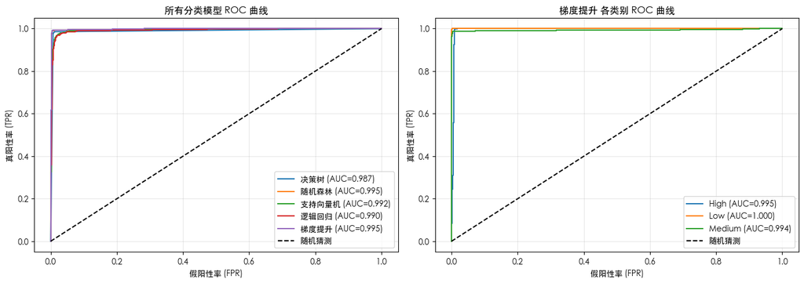

```
图片已保存至: ./Image/11_roc_curves.png
```

```python
fig, axes = plt.subplots(1, 2, figsize=(14, 5))

# 设置图例和轴标签字体
for ax in axes.flat:
    legend = ax.get_legend()
    if legend:
        for text in legend.get_texts():
            text.set_fontproperties(get_font())
    for label in ax.get_xticklabels():
        label.set_fontproperties(get_font())
    for label in ax.get_yticklabels():
        label.set_fontproperties(get_font())



ax1 = axes[0]
y_test_bin = label_binarize(y_test_clf, classes=class_labels)

for name, model in classification_models.items():
    if name in ['支持向量机', '逻辑回归']:
        y_pred_proba = model.predict_proba(X_test_clf_scaled)
    else:
        y_pred_proba = model.predict_proba(X_test_clf)

    fpr, tpr, _ = roc_curve(y_test_bin.ravel(), y_pred_proba.ravel())
    auc_val = roc_auc_score(y_test_bin, y_pred_proba, multi_class='ovr', average='weighted')
    ax1.plot(fpr, tpr, label=f'{name} (AUC={auc_val:.3f})')

ax1.plot([0, 1], [0, 1], 'k--', label='随机猜测')
ax1.set_xlabel('假阳性率 (FPR)', fontproperties=get_font())
ax1.set_ylabel('真阳性率 (TPR)', fontproperties=get_font())
ax1.set_title('所有分类模型 ROC 曲线', fontproperties=get_font(), fontsize=12, fontweight='bold')
ax1.legend(loc='lower right', prop=get_font())
ax1.grid(True, alpha=0.3)

ax2 = axes[1]
if best_clf_model_name in ['支持向量机', '逻辑回归']:
    y_pred_proba_best = best_clf_model.predict_proba(X_test_clf_scaled)
else:
    y_pred_proba_best = best_clf_model.predict_proba(X_test_clf)

for i, cls in enumerate(class_labels):
    fpr_cls, tpr_cls, _ = roc_curve(y_test_bin[:, i], y_pred_proba_best[:, i])
    auc_cls = roc_auc_score(y_test_bin[:, i], y_pred_proba_best[:, i])
    ax2.plot(fpr_cls, tpr_cls, label=f'{cls} (AUC={auc_cls:.3f})')

ax2.plot([0, 1], [0, 1], 'k--', label='随机猜测')
ax2.set_xlabel('假阳性率 (FPR)', fontproperties=get_font())
ax2.set_ylabel('真阳性率 (TPR)', fontproperties=get_font())
ax2.set_title(f'{best_clf_model_name} 各类别 ROC 曲线', fontproperties=get_font(), fontsize=12, fontweight='bold')
ax2.legend(loc='lower right', prop=get_font())
ax2.grid(True, alpha=0.3)

plt.tight_layout()
plt.savefig(f'{image_dir}11_roc_curves.png', dpi=150, bbox_inches='tight')
plt.show()
print(f"\n图片已保存至: {image_dir}11_roc_curves.png")
```

### 7.6 特征重要性分析

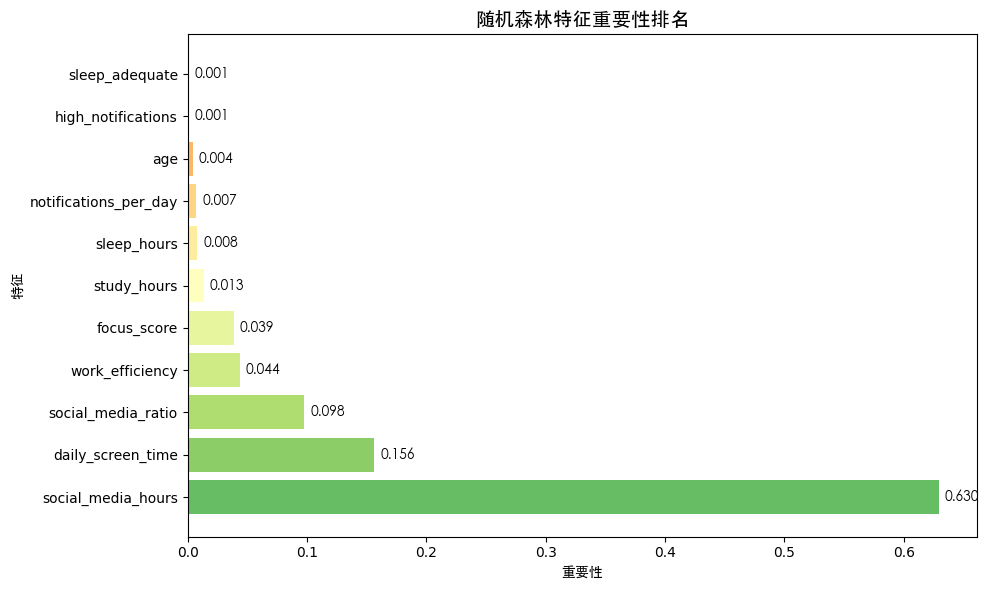

```
图片已保存至: ./Image/12_feature_importance.png

特征重要性排名:
              Feature  Importance
   social_media_hours    0.629573
    daily_screen_time    0.156298
   social_media_ratio    0.097717
      work_efficiency    0.043549
          focus_score    0.038648
          study_hours    0.013331
          sleep_hours    0.007982
notifications_per_day    0.007253
                  age    0.004383
   high_notifications    0.000753
       sleep_adequate    0.000513
```

```python
rf_clf = RandomForestClassifier(n_estimators=100, max_depth=10, random_state=42)
rf_clf.fit(X_train_clf, y_train_clf)

feature_importance = pd.DataFrame({
    'Feature': feature_cols,
    'Importance': rf_clf.feature_importances_
}).sort_values('Importance', ascending=False)

plt.figure(figsize=(10, 6))
colors = plt.cm.RdYlGn(np.linspace(0.2, 0.8, len(feature_importance)))[::-1]
bars = plt.barh(feature_importance['Feature'], feature_importance['Importance'], color=colors)
plt.xlabel('重要性', fontproperties=get_font())
plt.ylabel('特征', fontproperties=get_font())
plt.title('随机森林特征重要性排名', fontproperties=get_font(), fontsize=14, fontweight='bold')
for bar, val in zip(bars, feature_importance['Importance']):
    plt.text(val + 0.005, bar.get_y() + bar.get_height()/2, f'{val:.3f}',
             va='center', fontproperties=get_font())
plt.tight_layout()
plt.savefig(f'{image_dir}12_feature_importance.png', dpi=150, bbox_inches='tight')
plt.show()
print(f"\n图片已保存至: {image_dir}12_feature_importance.png")
print("\n特征重要性排名:")
print(feature_importance.to_string(index=False))
```

## 8. 总结与建议

### 8.1 回归模型总结

```python
best_reg = reg_results_df.iloc[0]

print("=" * 70)
print("回归模型性能总结")
print("=" * 70)
print(f"\n最佳模型: {best_reg['Model']}")
print(f"  - R² 得分: {best_reg['R2']:.4f}")
print(f"  - RMSE: {best_reg['RMSE']:.4f}")
print(f"  - MAE: {best_reg['MAE']:.4f}")
print(f"  - 交叉验证 R²: {best_reg['CV_R2_Mean']:.4f} (+/- {best_reg['CV_R2_Std']*2:.4f})")
print(f"  - 训练时间: {best_reg['Train_Time']:.4f}秒")

'''
import joblib
best_reg_model = regression_models[best_reg['Model']]
joblib.dump(best_reg_model, f'{model_dir}best_regression_model.pkl')
print(f"\n最佳回归模型已保存至: {model_dir}best_regression_model.pkl")
'''
```

```
======================================================================
回归模型性能总结
======================================================================

最佳模型: 随机森林回归
  - R² 得分: 0.8396
  - RMSE: 10.8740
  - MAE: 8.1346
  - 交叉验证 R²: 0.8408 (+/- 0.0163)
  - 训练时间: 0.2563秒
```

```
'\nimport joblib\nbest_reg_model = regression_models[best_reg[\'Model\']]\njoblib.dump(best_reg_model, f\'{model_dir}best_regression_model.pkl\')\nprint(f"\n最佳回归模型已保存至: {model_dir}best_regression_model.pkl")\n'
```